Dylan Fanelli, baseball operations. M.S. Sport Management, UMass Amherst (Isenberg / McCormack)

# Baseball research a club can use

These are original questions a front office pays to answer, built on every public pitch of 2024–2026 and every MLB trade since 2009. Each one is validated out of sample, checked number by number in a separate review pass, and shipped as code a club could run tomorrow. When the answer is no, the report says no.

**2.14M**regular-season pitches, 2024–26, with batter, location, base-out state and bat tracking

**15**finished studies, decision memos and scouting reports, each with its code and figures

**401**tests with hand-checked numbers, run on every push

**100%**of finished reports put through a separate review pass; the reviews changed real conclusions

Start here, the capstone

## One real decision, made the way a front office makes it

To: General manager, Texas RangersRe: Bullpen, 2026-27 offseasonData-informed; not a live look

**The need is late-inning run prevention.** Texas relievers fell from 4th in run value per 100 pitches in 2025 to 24th in 2026, and from 6th to 26th in late, close spots. Relievers now free agents or on a mutual option threw 35% of those late, close plate appearances. The memo ranks three free-agent relievers using every tool on this page: regressed results with intervals, stuff vs. results, velocity against the league, pitch-design levers, data-informed 20-80 grades, and prices from the reliever market's own line.

Tier A, pursue**Adrián Morejón**

Open at 4 years, $60M. Walk away above $72M, his value at the market's price of a win. That lands him about half the time, and the memo prices each step above it.

Tier B, if he signs elsewhere**Bryan Abreu**

Open at 2 years, $18M; walk away above $25M. His walk rate fell from 19.7% to 11.3% in the second half of 2026, but that drop is borderline (p = 0.058), so it's priced as a lean.

Tier C, not for 2027**Pete Fairbanks**

Thoracic outlet surgery, announced Sept. 19, 2026. At most a two-year rehab deal.

[figure not shown]

[Read the memo →](https://github.com/IForSureI/Dylan-Fanelli-Baseball-Analytics-Portfolio/blob/main/reports/2026-bullpen-acquisition-memo.md)

The research

## Questions, answers, and the evidence for each

Evaluation, original study

### Does a pitch wear out on a hitter?

**Yes, and it's specific to the pitch type.** An earlier changeup or splitter a hitter saw from the pitcher in earlier plate appearances today, in place of a pitch of another type, goes with 1.87 fewer whiff points on the next one. Pitches of other types in earlier plate appearances go with slightly more whiffs, not fewer. The effect carries across games this season and partly to the next same-handed pitcher's changeup. It holds in each of the three seasons, and with platoon and month-level fixed effects.

−1.87 whiff pts per earlier changeup/splitter−8.2 after 4+42% carries to the next same-handed pitcher

[Read the report →](https://github.com/IForSureI/Dylan-Fanelli-Baseball-Analytics-Portfolio/blob/main/reports/2026-league-pitch-familiarity.md)

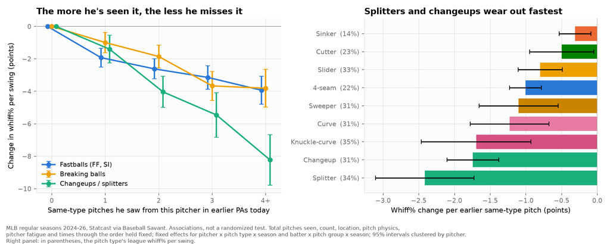

In-game strategy, a reported null

### Should that change when the starter comes out?

**No.** Costs were fit on 2024–25 and tested on 2026. The per-pitch cost replicates, but it doesn't reach plate-appearance run value, and managers show no detectable response to it. The report also shows something managers do act on: run value allowed so far, which has no detectable association with the next plate appearance among the starters they leave in.

2026 calibration slope −0.28 (SE 0.37)removal response −0.15 (SE 0.27)

[Read the report →](https://github.com/IForSureI/Dylan-Fanelli-Baseball-Analytics-Portfolio/blob/main/reports/2026-exposure-aware-hook.md)

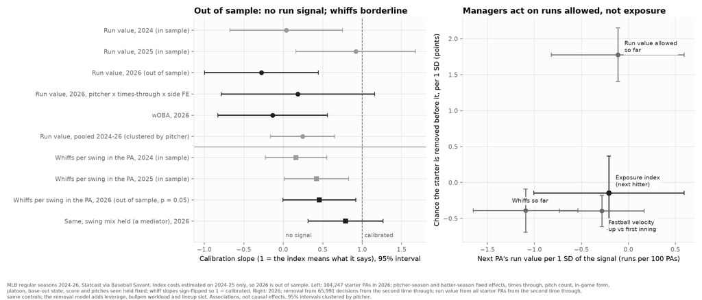

Evaluation, pre-registered

### Do hitters adapt to shapes they've seen from other pitchers?

**The planned test can't say, and the report leads with that.** The plan was committed before any fit and 2026 was held out. The raw association replicated, then failed its own placebo: shapes a hitter is about to see predict his whiffs too, which points to who plays against what. An exploratory follow-up that holds his season-long diet fixed finds a small recent effect, about a quarter of a whiff point per SD, worth about 2 runs a season at most. Don't reorder a bullpen on it.

[Read the report →](https://github.com/IForSureI/Dylan-Fanelli-Baseball-Analytics-Portfolio/blob/main/reports/2026-shape-exposure.md)

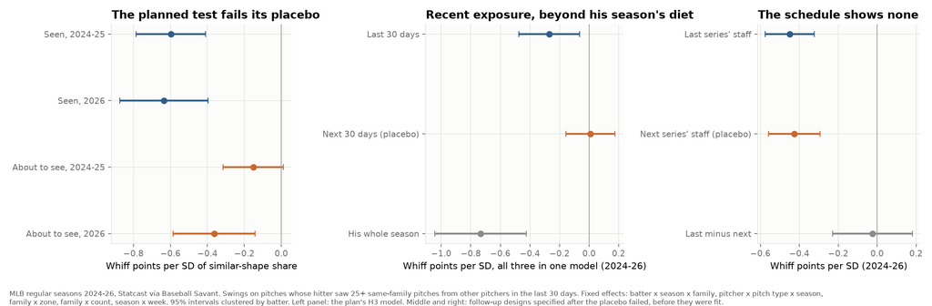

Evaluation, the analyst's reference

### Which numbers can you trust, and when?

**The Reliability Atlas covers 29 metrics in 157 groups.** For each, it measures how fast the metric becomes signal, how much carries into next season, how much true talent moves within a season, and how far to regress it, with a regress() function that returns intervals. Regressing beat raw numbers out of sample for 135 of 147 groups, and a clean 2024 → 2025 replication agrees. Pitch physics are regressed by games, not pitches: one 100-pitch outing is one look.

bat speed: r = 0.5 after ~3 swingswOBA: ~500 PA for r = 0.5 (extrapolated)135 / 147 better than raw

[Read the atlas →](https://github.com/IForSureI/Dylan-Fanelli-Baseball-Analytics-Portfolio/blob/main/reports/2026-reliability-atlas.md)

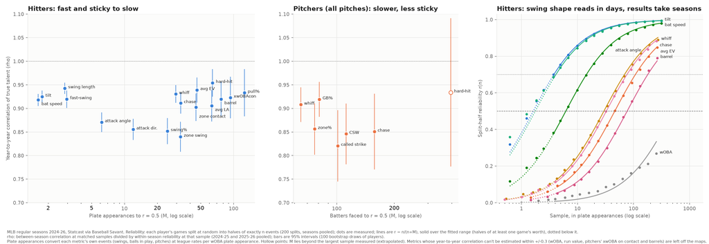

Player development

### Which pitch-design changes stick and pay?

**Four-seam ride is the best-supported lever.** It's worth +1.62 whiff points per 2 inches, and the gain's point estimate held into year two. Velocity's payoff fails a placebo, so recovery from a down year isn't ruled out. Slider levers pay but aren't shown to last. Given the shape change, the single change in expected whiff predicts next season's whiff change better than the full lever model, pooled across pitch types. Also built: an individual development plan engine that issues on-track, behind, flat and inconclusive verdicts and checks power when the plan is written.

FF ride +1.62 per 2 in (q = 0.02)velocity: placebo fails1,822 season-to-season pitch pairs

[Read the report →](https://github.com/IForSureI/Dylan-Fanelli-Baseball-Analytics-Portfolio/blob/main/reports/2026-pitch-design-levers.md)

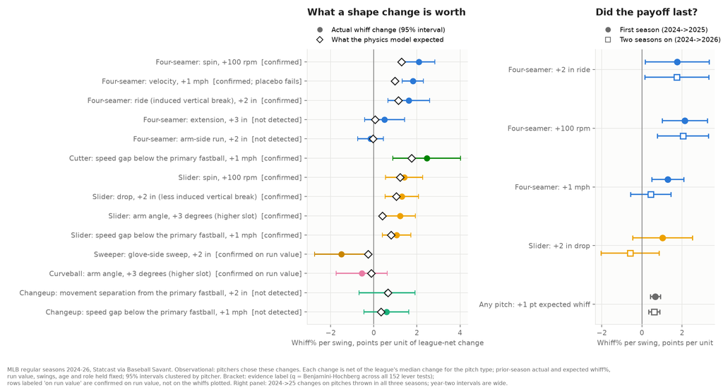

Roster and the CBA

### Extend Paul Skenes before December 1?

**Open at about $200M in present value; walk away above about $215M.** The price depends on the next Basic Agreement, so the memo prices both rule sets and a major-arm-injury scenario. Underneath is the CBA as code: service time, Super Two, options, Rule 5, outright and 10-and-5 rights, qualifying offers and the luxury tax. The tax engine reproduces the published 2025 bills within $1 for eight of the nine clubs that paid.

8 of 9 tax bills within $1open ~$200M PV, walk ~$215M PV

[Read the memo →](https://github.com/IForSureI/Dylan-Fanelli-Baseball-Analytics-Portfolio/blob/main/reports/2026-roster-cba-engine.md)

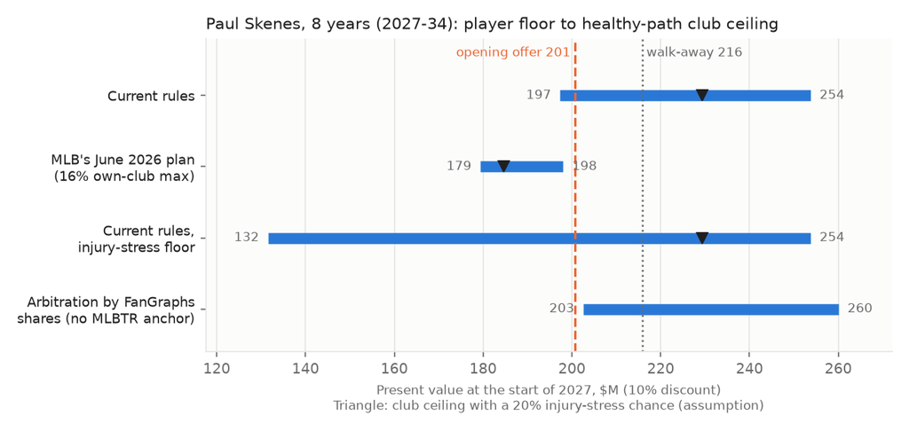

Trades, a graph of every deal since 2009

### Who trades with whom?

[Read the report →](https://github.com/IForSureI/Dylan-Fanelli-Baseball-Analytics-Portfolio/blob/main/reports/2026-trade-network-rivals.md)

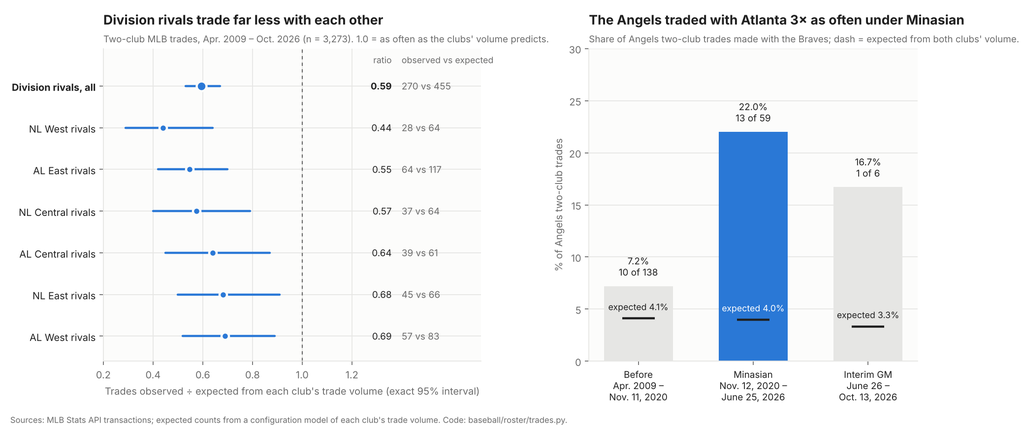

Trades, front offices

### Do front-office ties predict trade partners?

any tie 1.18 (1.04–1.34)permutation p = 0.015protégé tie: borderline

[Read the report →](https://github.com/IForSureI/Dylan-Fanelli-Baseball-Analytics-Portfolio/blob/main/reports/2026-front-office-ties.md)

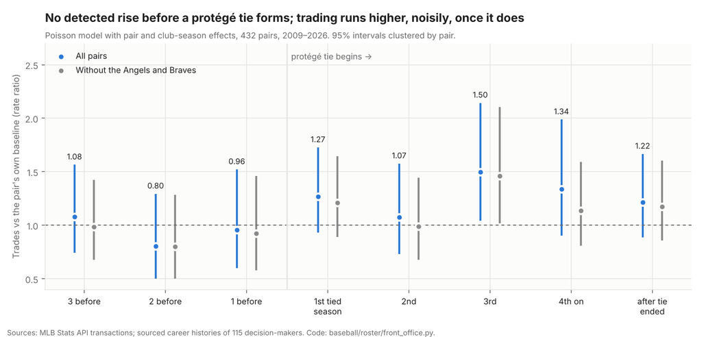

Front offices, graph

### Whose front offices did today's heads of baseball operations come through?

**Cleveland's, more than any other club's.** Fifteen future heads worked in Cleveland's front office before their first head job, and nine hold a club's top baseball-operations job today. John Hart's tree, from Cleveland and then Texas, reaches 21 of today's 38 within three generations and ranks first on PageRank in Neo4j's Graph Data Science. Since 2009 the median head took 14 years from his first recorded front-office job, 75% held an assistant GM title first, and 58% were promoted from inside.

CLE: 15 future heads, 9 todaymedian 14 years to the chair

[Read the report →](https://github.com/IForSureI/Dylan-Fanelli-Baseball-Analytics-Portfolio/blob/main/reports/2026-gm-tree.md)

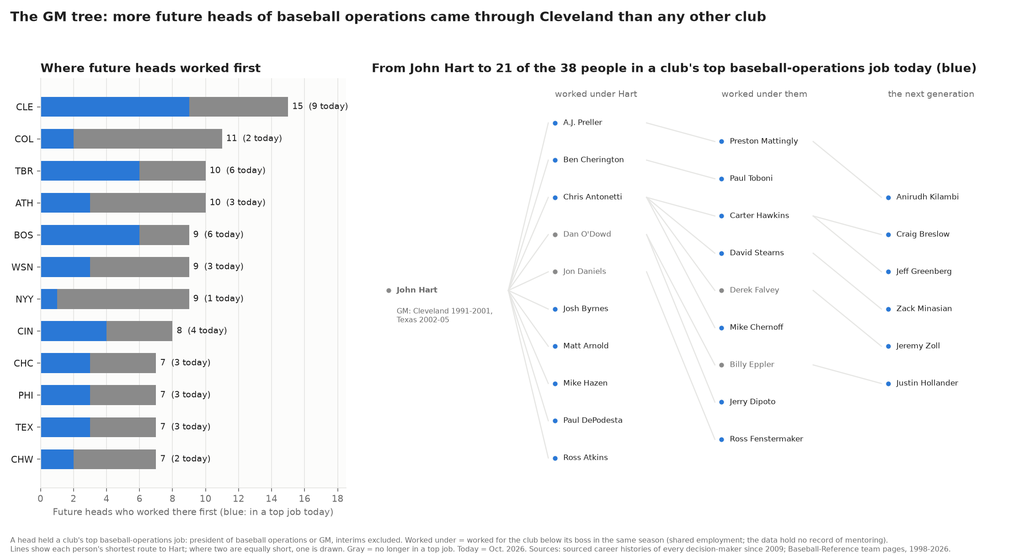

Pro scouting

### What would a pro scout write on the top free-agent reliever?

**Adrián Morejón: OFP 60, a B1 reliever for 2027.** The sinker, changeup and four-seamer grade 70 on the 20-80 scale, each move off its measured base stated. Statcast labeled a version of his changeup a knuckleball in 2024. The slider's whiffs fell from 40% to 30% as it got harder and lost 2.7 inches of drop, while its release stayed as distinct as in its best year. Delivery items that need eyes are graded NG, and the video look comes before the bid.

OFP 60, B1changeup 56% whiff, 182 swingsdelivery: NG until a look

[Read the report →](https://github.com/IForSureI/Dylan-Fanelli-Baseball-Analytics-Portfolio/blob/main/reports/2026-morejon-pro-scouting-report.md), [One page →](https://github.com/IForSureI/Dylan-Fanelli-Baseball-Analytics-Portfolio/blob/main/reports/2026-morejon-pro-scouting-report.pdf)

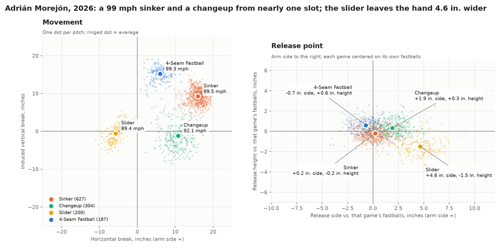

Pitcher evaluation

### Was Tarik Skubal's 2025 change real?

**Yes, and the change was his.** He ranked at the 80th–98th percentile on the changes while the league didn't move, and he raised his arm slot on everything but the changeup. His changeup's whiff rate is his true level: 46.6% on 997 swings across two seasons.

changeup 46.6% whiff, 997 swings

[Read the report →](https://github.com/IForSureI/Dylan-Fanelli-Baseball-Analytics-Portfolio/blob/main/reports/2025-skubal-arsenal.md)

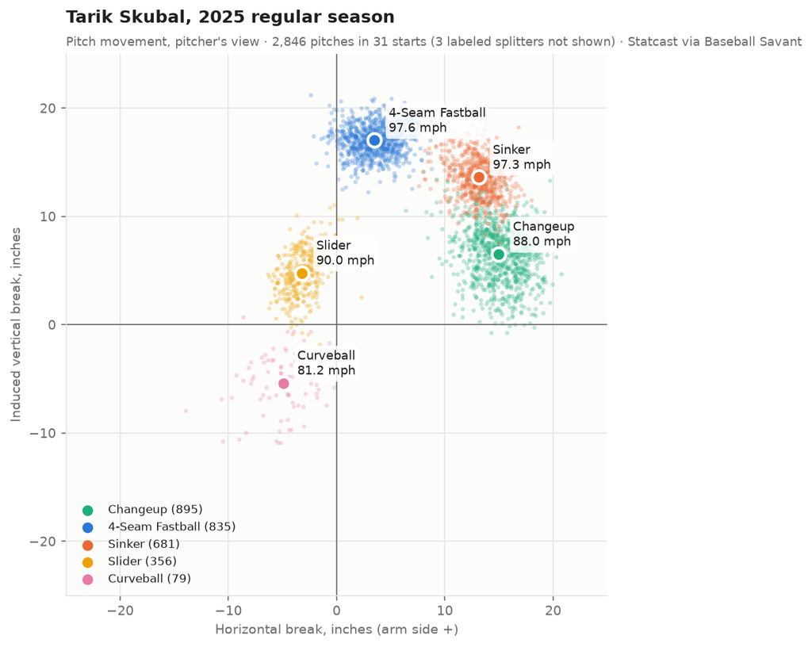

Advance scouting

### How should a club pitch the Rays' lineup in the ALCS?

**In the zone, for weak contact.** The nine regulars missed on 19.9% of their swings against a league rate of 25.1%, and their contact was soft (.331 xwOBA, league .362). The usual put-away pitch, a breaking ball below the zone, gets 17.4 swinging strikes per 100 against the league's 23.2. Every hitter gets a card with his n, and the plan comes as a one-page coach version in English and in Spanish.

19.9% whiff, 8,327 swingscoach page in English and Spanish

[Read the packet →](https://github.com/IForSureI/Dylan-Fanelli-Baseball-Analytics-Portfolio/blob/main/reports/2026-advance-packet-tb.md), [Coach page →](https://github.com/IForSureI/Dylan-Fanelli-Baseball-Analytics-Portfolio/blob/main/reports/2026-advance-packet-tb-coach.md), [En español →](https://github.com/IForSureI/Dylan-Fanelli-Baseball-Analytics-Portfolio/blob/main/reports/2026-advance-packet-tb-coach-es.md)

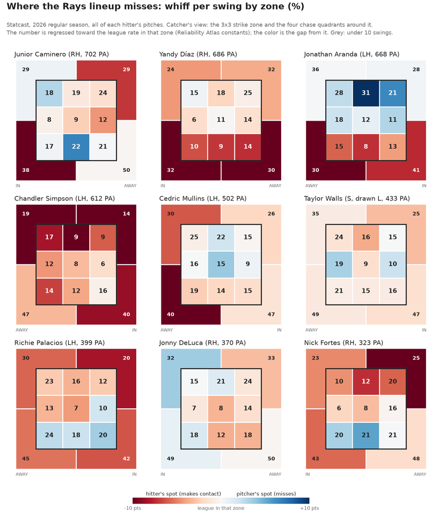

Arbitration

### What should a club file in Cade Smith's first arbitration case?

**$4.65M; settle at $5.0-5.1M; go to a hearing above $5.1M.** The comp pool comes from a stated rule: every reliever with 20 saves in a platform year since 2015 who was going into his first arbitration year. It puts him at $4.58M, and the club wins at a $5.275M midpoint about 60% of the time. The brief works the 2022-26 agreement's criteria, what a panel can't hear, and the second-year closers his side would cite. The same code works a second case, Toronto's Super Two closer Louis Varland: file $3.65M against a $3.58M comp line and MLB Trade Rumors' $3.8M, and the club is favored (61%) under any weighting. Independent exercises from public data.

23 comps, leave-one-out error 16%P(club wins) 0.60

[Read the Smith brief →](https://github.com/IForSureI/Dylan-Fanelli-Baseball-Analytics-Portfolio/blob/main/reports/2027-arbitration-brief-smith.md) · [Read the Varland brief →](https://github.com/IForSureI/Dylan-Fanelli-Baseball-Analytics-Portfolio/blob/main/reports/2027-arbitration-brief-varland.md)

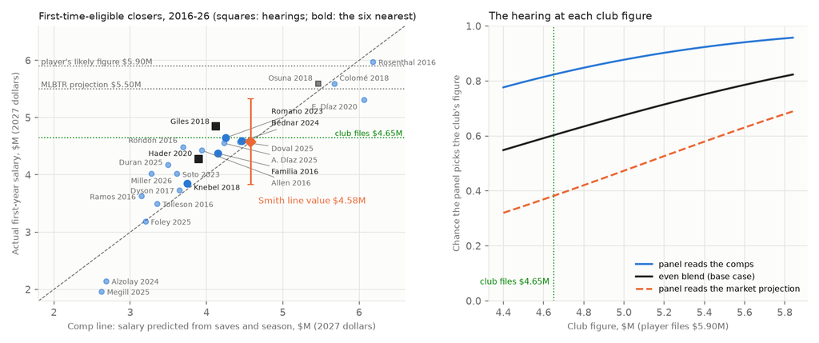

Hitter evaluation

### Do good swing decisions last, and what is Gleyber Torres worth?

**They last, and Torres is worth two years at $28-32M.** Decision value repeats year to year (r = 0.80 from 2025 to 2026). Torres's decisions are among the best in baseball, but his bat lost 2 mph in 2026. With baserunning, he projects to 1.50 WAR for 2027, priced at one rate per win so a quarter of a run can't move the value by millions. Walk away above $17M a year.

decision value r 0.801.50 WAR, 2 yrs $29.6M

[Read the evaluation →](https://github.com/IForSureI/Dylan-Fanelli-Baseball-Analytics-Portfolio/blob/main/reports/2026-hitter-evaluation-torres.md)

[figure not shown]

How the work is held up

## The standard

- **Out of sample by default.** Forecasts are tested on seasons their parameters never saw, against a regressed baseline.
- **One evidence standard.** Confirmed means p < 0.05 with enough sample. Benjamini–Hochberg is applied when many tests run at once. "No sign of an effect" is claimed only when the interval rules out effects that matter.
- **Pooling and regression rules.** Seasons are pooled only with standard errors clustered by pitcher, and small samples are regressed before they're compared.
- **Placebos and matched controls** guard against regression to the mean and selection.
- **Plans written down first.** The shape-exposure study committed its analysis plan before any fit and held out 2026; when the planned test failed its placebo, the report led with it.
- **Public data only.** Statcast via Baseball Savant, MLB Stats API transactions, Baseball-Reference and Retrosheet, plus cited, dated public reporting for contracts, transactions and executive careers.

Separate review passes

## What review changed

| Study | Caught | Result |
| --- | --- | --- |
| Skenes memo | The club's ceiling was defined one way and computed another. | The recommendation moved from a $216M offer to opening at $200M. |
| Pitch design | A lever that fails its placebo was ranked first. | Ride now leads; velocity carries a caveat. |
| Reliability | The noise model held for outcomes but broke for pitch physics. | Physics now use a two-level model (day and pitch) and are regressed by games. |
| Front-office ties | Trades were dated by calendar year and jobs by season, so a new GM's first offseason deals with his old club scored as untied. | One season calendar for both; the protégé tie is reported as borderline, not confirmed. |
| Bullpen memo | The health history check was uneven across candidates. | A free agent's surgery took him out of 2027. |

The toolkit

## Everything above runs from one command

[output not shown]